# Spatial correlation - large scale minimal examples

Thomas Bury Human Bender DS

2019-07-12

[figure not shown]

# 1 Introduction

I provide two minimal examples to compare discrete and continuous smoothing to figure out the differences. The discrete will be performed by fitting a Beta regression using a GAM with Gaussian Markov Random Fields (GMRF) as basis. The MRF are the discrete counterpart of Gaussian processes (GP).

- The GMRF smoothing requires a mesh grid (the graph/network/lattice call it as you like) to build and estimate the response based on the Markov blanket.
- The GP smoothing takes the coordinates as input (so continuous input) to estimate the response using Gaussian processes.

N.B: I don’t provide here methodologically exact examples (with train-test split and cross-validation to find hyper-parameters for instance). It would involve a bit more work and more CPU time and computation power.

# 2 Us unemployment rate - Large scale examples

## 2.1 Continuous smoothing - unemployment rate

```r
# Load the USmap
unemp <- read.csv("http://datasets.flowingdata.com/unemployment09.csv",
                  header = FALSE, stringsAsFactors = FALSE)
names(unemp) <- c("id", "state_fips", "county_fips", "name", "year",
                  "?", "?", "?", "rate")
unemp$county <- tolower(gsub(" County, [A-Z]{2}", "", unemp$name))
unemp$county <- gsub("^(.*) parish, ..$","\\1", unemp$county)
unemp$state <- gsub("^.*([A-Z]{2}).*$", "\\1", unemp$name)
county_df <- map_data("county", projection = "albers", parameters = c(39, 45))

# Build the choropleth and the states borders
names(county_df) <- c("long", "lat", "group", "order", "state_name", "county")
county_df$state <- state.abb[match(county_df$state_name, tolower(state.name))]
county_df$state_name <- NULL
state_df <- map_data("state", projection = "albers", parameters = c(39, 45))
choropleth <- merge(county_df, unemp, by = c("state", "county"))
choropleth <- setDT(choropleth[order(choropleth$order), ])
choropleth <- choropleth[, pct := rate/100]

roughness_param = 300

# The m argument allows to specify different types of covariance functions.
gam_gp = gam(pct ~ s(long, lat, bs='gp', k=roughness_param, m=1), data=choropleth)
summary(gam_gp)
```

```
##
## Family: gaussian
## Link function: identity
##
## Formula:
## pct ~ s(long, lat, bs = "gp", k = roughness_param, m = 1)
##
## Parametric coefficients:
##              Estimate Std. Error t value Pr(>|t|)
## (Intercept) 0.0911135  0.0000649    1404   <2e-16 ***
## ---
## Signif. codes:  0 '***' 0.001 '**' 0.01 '*' 0.05 '.' 0.1 ' ' 1
##
## Approximate significance of smooth terms:
##             edf Ref.df     F p-value
## s(long,lat) 299    299 551.2  <2e-16 ***
## ---
## Signif. codes:  0 '***' 0.001 '**' 0.01 '*' 0.05 '.' 0.1 ' ' 1
##
## R-sq.(adj) =  0.656   Deviance explained = 65.7%
## GCV = 0.00036447  Scale est. = 0.0003632  n = 86225
```

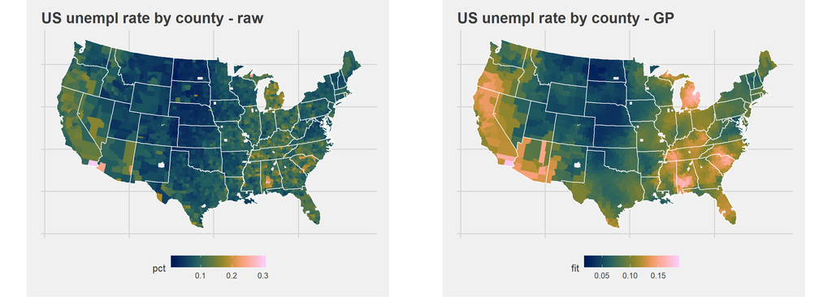

```r
# Add the prediction to the data.frame
choropleth = choropleth %>%
  mutate(fit = predict(gam_gp, type='response'))
choropleth = setDT(choropleth)


# The base plot
plot_county_smoothed_GP <- ggplot(choropleth, aes(long, lat, group = group)) +
  geom_polygon(aes(fill = fit)) +
  geom_polygon(data = state_df, colour = "white", fill = NA, size = .5) +
  coord_fixed() +
  theme_minimal() +
  ggtitle("US unempl rate by county - GP") + theme_fivethirtyeight() +
  guides(fill = guide_colorbar(barwidth = 8, barheight = 1)) +
  theme(axis.line = element_blank(), axis.text = element_blank(),
        axis.ticks = element_blank(), axis.title = element_blank()) +
  scale_fill_scico(palette = "batlow")

plot_county_raw <- ggplot(choropleth, aes(long, lat, group = group)) +
  geom_polygon(aes(fill = pct)) +
  geom_polygon(data = state_df, colour = "white", fill = NA, size = .5) +
  coord_fixed() +
  theme_minimal() +
  ggtitle("US unempl rate by county - raw") + theme_fivethirtyeight() +
  guides(fill = guide_colorbar(barwidth = 8, barheight = 1)) +
  theme(axis.line = element_blank(), axis.text = element_blank(),
        axis.ticks = element_blank(), axis.title = element_blank()) +
  scale_fill_scico(palette = "batlow")

plot_grid(plot_county_raw, plot_county_smoothed_GP)
```

Let’s perform the discrete smoothing on the same data set to picture the differences.

## 2.2 Discrete smoothing - unemployment rate

```r
# Load the USmap
unemp <- read.csv("http://datasets.flowingdata.com/unemployment09.csv",
                  header = FALSE, stringsAsFactors = FALSE)
names(unemp) <- c("id", "state_fips", "county_fips", "name", "year",
                  "?", "?", "?", "rate")
unemp$county <- tolower(gsub(" County, [A-Z]{2}", "", unemp$name))
unemp$county <- gsub("^(.*) parish, ..$","\\1", unemp$county)
unemp$state <- gsub("^.*([A-Z]{2}).*$", "\\1", unemp$name)
county_df <- map_data("county", projection = "albers", parameters = c(39, 45))

# Build the choropleth and the states borders
names(county_df) <- c("long", "lat", "group", "order", "state_name", "county")
county_df$state <- state.abb[match(county_df$state_name, tolower(state.name))]
county_df$state_name <- NULL
state_df <- map_data("state", projection = "albers", parameters = c(39, 45))
choropleth <- merge(county_df, unemp, by = c("state", "county"))
choropleth <- setDT(choropleth[order(choropleth$order), ])
choropleth <- choropleth[, `:=`(pct = rate/100, GEOID = as.factor(paste0(state,  county)) )]

# group by county
county_data <- choropleth[, lapply(.SD, median), by = GEOID, .SDcols = c('long', 'lat', 'pct')]
# Build the lattice
xy <- cbind(county_data$long, county_data$lat)

nb <- spdep::tri2nb(xy, row.names = county_data$GEOID)
```

[output not shown]

```r
names(nb) <- attr(nb, "region.id")

# The m argument allows to specify different types of covariance functions.
ctrl <- gam.control(nthreads = 6) # use 6 parallel threads, reduce if fewer physical CPU cores

# Fitting the GAM beta regression with GMRF as basis (discrete version of GP)
# Try to change the roughness param to see the effect
#
# roughness_param == should be an integer, the lower the smoother the plot (the rank of the MRF, the lower the rank the smoother)
#                    if you remove k-param from the below fit, the fit will be done with full rand GMRF
#
roughness_param = 100
gam_mrf <- gam(pct ~ s(GEOID, bs = 'mrf', k = roughness_param, xt = list(nb = nb)), # define MRF smooth
               data = county_data,
               method = 'REML',
               family = betar,  # fit a beta regression
               control = ctrl)
# Print out the summary
summary(gam_mrf)
```

```
##
## Family: Beta regression(203.472)
## Link function: logit
##
## Formula:
## pct ~ s(GEOID, bs = "mrf", k = roughness_param, xt = list(nb = nb))
##
## Parametric coefficients:
##              Estimate Std. Error z value Pr(>|z|)
## (Intercept) -2.389952   0.004645  -514.5   <2e-16 ***
## ---
## Signif. codes:  0 '***' 0.001 '**' 0.01 '*' 0.05 '.' 0.1 ' ' 1
##
## Approximate significance of smooth terms:
##            edf Ref.df Chi.sq p-value
## s(GEOID) 90.83     99   4789  <2e-16 ***
## ---
## Signif. codes:  0 '***' 0.001 '**' 0.01 '*' 0.05 '.' 0.1 ' ' 1
##
## R-sq.(adj) =  0.594   Deviance explained = 66.2%
## -REML =  -7543  Scale est. = 1         n = 3019
```

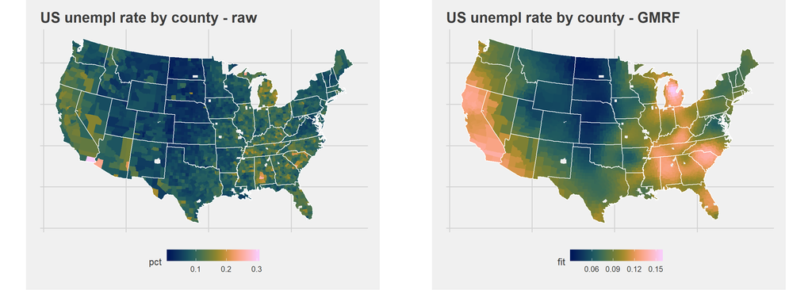

```r
# Add the prediction to the data.frame, just predict for the counties then join the choropleth to avoid predicting
# several times the same row
county_data = county_data %>%
  mutate(fit = predict(gam_mrf, type='response'))
county_data = setDT(county_data)
county_data = county_data[, .(GEOID, fit)]

# Joining prediction to the map_data df. This map_data df is just the same as the shape file but easier to plot with ggplot2
plotdat = choropleth %>%
  left_join(county_data, by = c('GEOID' = 'GEOID'))

# define the plot. Note that since I did the minimal example, ggplot comes natively with a new geom called
# "geom_sf" no need to convert data into interpretable polygons
plot_county_smoothed_GMRF <- ggplot(plotdat, aes(long, lat, group = group)) +
  geom_polygon(aes(fill = fit)) +
  geom_polygon(data = state_df, colour = "white", fill = NA, size = .5) +
  coord_fixed() +
  theme_minimal() +
  ggtitle("US unempl rate by county - GMRF") + theme_fivethirtyeight() +
  guides(fill = guide_colorbar(barwidth = 8, barheight = 1)) +
  theme(axis.line = element_blank(), axis.text = element_blank(),
        axis.ticks = element_blank(), axis.title = element_blank()) +
  scale_fill_scico(palette = "batlow")

plot_grid(plot_county_raw, plot_county_smoothed_GMRF)
```

Let’s compare the continuous and discrete smoothings (GP vs GMRF)

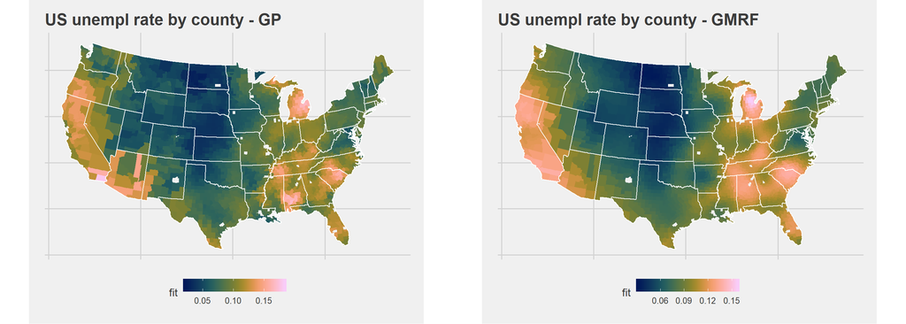

```r
plot_grid(plot_county_smoothed_GP, plot_county_smoothed_GMRF)
```

# 3 Us education level - Large scale examples

## 3.1 Discrete smoothing - education level

A beautiful example here: https://www.fromthebottomoftheheap.net/2017/10/19/first-steps-with-mrf-smooths/ but takes time to run (for an unknown reason some states are missing in the provided data set but present in the example shown on the webpage).

### 3.1.1 Few states

```r
# Load the data, for an unknownreason the file download from the github does not report results for
# California and a couple of other states
data_path = "C:/Users/xtbury/Documents/Projects/Italy projects/002_Zoning/Data files/"
file_name = "us_county_hs_only/us_county_hs_only.shp"

shp <- rgdal::readOGR(paste0(data_path, file_name))
```

```r
# If necessary, you can load the whole US shapefile
# shp <- rgdal::readOGR('D:/Users/EUDZ040/R/002_Zoning/Data files/us_county_hs_only/cb_2017_us_county_500k.shp')

# Let's choose some states according to the ANSI code
states_num <- c(26,33,34,36)
shp <- shp[shp$STATEFP %in% states_num, ]
# Here is the mapping table code <-> name
data_path = "C:/Users/xtbury/Documents/Projects/Italy projects/002_Zoning/Data files/"
file_name = "us-state-ansi-fips.csv"
path_full = paste0(data_path, file_name)

states_names <- fread(path_full)
# Data prep
states_names$stname <- tolower(states_names$stname)
states_names <- states_names[st %in% states_num]
colnames(states_names) <- c('stname', 'STATEFP', 'stusps')

# select the states, and convert % to proportion
states_df <-  shp %>%   # add other FIPS codes as desired
  as.data.frame() %>%
  droplevels() %>%
  mutate(hsd = hs_pct / 100,
         county = stringr::str_replace(tolower(NAME), pattern='\\.', ''),
         county = factor(county))
nb <- spdep::poly2nb(shp, row.names = states_df$GEOID)
names(nb) <- attr(nb, "region.id")
ctrl <- gam.control(nthreads = 6) # use 6 parallel threads, reduce if fewer physical CPU cores

# Fitting the GAM beta regression with GMRF as basis (discrete version of GP)
# Try to change the roughness param to see the effect
#
# roughness_param == should be an integer, the lower the smoother the plot (the rank of the MRF, the lower the rank the smoother)
#                    if you remove k-param from the below fit, the fit will be done with full rand GMRF
#
roughness_param = 20
gam_mrf <- gam(hsd ~ s(GEOID, bs = 'mrf', k = roughness_param, xt = list(nb = nb)), # define MRF smooth
               data = states_df,
               method = 'REML',
               family = betar,  # fit a beta regression
               control = ctrl)

# Print out the summary
summary(gam_mrf)
```

```
##
## Family: Beta regression(78.046)
## Link function: logit
##
## Formula:
## hsd ~ s(GEOID, bs = "mrf", k = roughness_param, xt = list(nb = nb))
##
## Parametric coefficients:
##             Estimate Std. Error z value Pr(>|z|)
## (Intercept) -0.67485    0.01796  -37.57   <2e-16 ***
## ---
## Signif. codes:  0 '***' 0.001 '**' 0.01 '*' 0.05 '.' 0.1 ' ' 1
##
## Approximate significance of smooth terms:
##            edf Ref.df Chi.sq  p-value
## s(GEOID) 13.54  16.74  84.01 3.95e-11 ***
## ---
## Signif. codes:  0 '***' 0.001 '**' 0.01 '*' 0.05 '.' 0.1 ' ' 1
##
## R-sq.(adj) =  0.336   Deviance explained = 38.6%
## -REML = -247.17  Scale est. = 1         n = 176
```

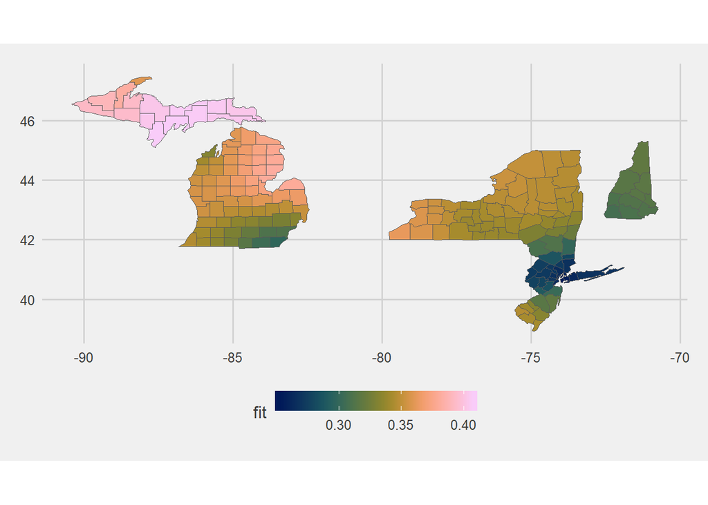

```r
# Add the prediction to the data.frame
states_df = states_df %>%
  mutate(fit = predict(gam_mrf, type='response'))
states_df = setDT(states_df)

# Joining data, the data.table way
states_names$STATEFP <- as.factor(states_names$STATEFP)
states_df = states_names[states_df, on = 'STATEFP']

# Joining prediction to the map_data df. This map_data df is just the same as the shape file but easier to plot with ggplot2
plotdat = map_data("county", states_names$stname) %>%
  left_join(states_df, by = c('region' = 'stname', 'subregion' = 'county'))

# We want to plot by county, so we need to group by subregion
sub_reg_data_mich <- plotdat %>% group_by(GEOID)

# define the plot. Note that since I did the minimal example, ggplot comes natively with a new geom called
# "geom_sf" no need to convert data into interpretable polygons
map_p1 <- ggplot(data = sub_reg_data_mich, # the input data
                 aes(x = long, y = lat, fill = fit, group = group)) +
          geom_polygon() + # plot the boroughs
          geom_path(colour="grey35", lwd=0.05) + # borough borders
          coord_equal() + # fixed x and y scales
          scale_fill_scico(palette = "batlow") +
          theme_fivethirtyeight() +
          guides(fill = guide_colorbar(barwidth = 10, barheight = 1))


# print out the graphic
map_p1
```

### 3.1.2 Almost the whole country

```r
# Load the data, for an unknownreason the file download from the github does not report results for
# California and a couple of other states
data_path = "C:/Users/xtbury/Documents/Projects/Italy projects/002_Zoning/Data files/"
file_name = "us_county_hs_only/us_county_hs_only.shp"
path_full = paste0(data_path, file_name)

shp <- rgdal::readOGR(path_full)
```

```r
# If necessary, you can load the whole US shapefile
# shp <- rgdal::readOGR('D:/Users/EUDZ040/R/002_Zoning/Data files/us_county_hs_only/cb_2017_us_county_500k.shp')

# Let's choose some states according to the ANSI code
states_num <- c(1,4:6, 8:13, 16:42, 44:51, 53:56)
shp <- shp[shp$STATEFP %in% states_num, ]
# Here is the mapping table code <-> name
data_path = "C:/Users/xtbury/Documents/Projects/Italy projects/002_Zoning/Data files/"
file_name = "us-state-ansi-fips.csv"
path_full = paste0(data_path, file_name)
states_names <- fread(paste0(data_path, file_name))

# Data prep
states_names$stname <- tolower(states_names$stname)
states_names <- states_names[st %in% states_num]
colnames(states_names) <- c('stname', 'STATEFP', 'stusps')

# select the states, and convert % to proportion
states_df <-  shp %>%   # add other FIPS codes as desired
  as.data.frame() %>%
  droplevels() %>%
  mutate(hsd = hs_pct / 100,
         county = stringr::str_replace(tolower(NAME), pattern='\\.', ''),
         county = factor(county))
nb <- spdep::poly2nb(shp, row.names = states_df$GEOID)
names(nb) <- attr(nb, "region.id")
ctrl <- gam.control(nthreads = 6) # use 6 parallel threads, reduce if fewer physical CPU cores

# Fitting the GAM beta regression with GMRF as basis (discrete version of GP)
# Try to change the roughness param to see the effect
#
# roughness_param == should be an integer, the lower the smoother the plot (the rank of the MRF, the lower the rank the smoother)
#                    if you remove k-param from the below fit, the fit will be done with full rand GMRF
#
roughness_param = 100
gam_mrf <- gam(hsd ~ s(GEOID, bs = 'mrf', k = roughness_param, xt = list(nb = nb)), # define MRF smooth
               data = states_df,
               method = 'REML',
               family = betar,  # fit a beta regression
               control = ctrl)
# Print out the summary
summary(gam_mrf)
```

```
##
## Family: Beta regression(68.191)
## Link function: logit
##
## Formula:
## hsd ~ s(GEOID, bs = "mrf", k = roughness_param, xt = list(nb = nb))
##
## Parametric coefficients:
##              Estimate Std. Error z value Pr(>|z|)
## (Intercept) -0.621066   0.004758  -130.5   <2e-16 ***
## ---
## Signif. codes:  0 '***' 0.001 '**' 0.01 '*' 0.05 '.' 0.1 ' ' 1
##
## Approximate significance of smooth terms:
##            edf Ref.df Chi.sq p-value
## s(GEOID) 87.32     99   1364  <2e-16 ***
## ---
## Signif. codes:  0 '***' 0.001 '**' 0.01 '*' 0.05 '.' 0.1 ' ' 1
##
## R-sq.(adj) =  0.339   Deviance explained = 35.6%
## -REML = -3953.8  Scale est. = 1         n = 2821
```

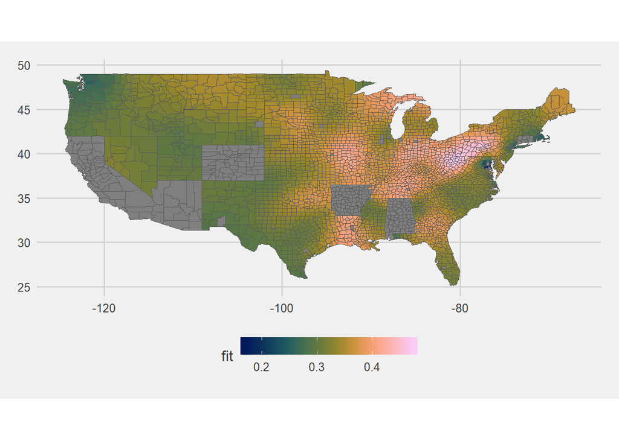

```r
# Add the prediction to the data.frame
states_df = states_df %>%
  mutate(fit = predict(gam_mrf, type='response'))
states_df = setDT(states_df)

# Joining data, the data.table way
states_names$STATEFP <- as.factor(states_names$STATEFP)
states_df = states_names[states_df, on = 'STATEFP']

# Joining prediction to the map_data df. This map_data df is just the same as the shape file but easier to plot with ggplot2
plotdat = map_data("county", states_names$stname) %>%
  left_join(states_df, by = c('region' = 'stname', 'subregion' = 'county'))

# We want to plot by county, so we need to group by subregion
sub_reg_data_mich <- plotdat %>% group_by(GEOID)

# define the plot. Note that since I did the minimal example, ggplot comes natively with a new geom called
# "geom_sf" no need to convert data into interpretable polygons
map_p2 <- ggplot(data = sub_reg_data_mich, # the input data
                 aes(x = long, y = lat, fill = fit, group = group)) +
          geom_polygon() + # plot the boroughs
          geom_path(colour="grey35", lwd=0.05) + # borough borders
          coord_equal() + # fixed x and y scales
          scale_fill_scico(palette = "batlow") +
          theme_fivethirtyeight() +
          guides(fill = guide_colorbar(barwidth = 10, barheight = 1))


# print out the graphic
map_p2
```